# GO Enrichment of differentially expressed genes of Aphedius ervi

Nanda Vo

## Load needed libraries

```r
# Load necessary libraries
library(dplyr)
library(readr)  # for reading the file
library(stringr)  # for string manipulation
library(tibble)
library(topGO)
library(ggplot2)


# Set knitr root directory for knitting
knitr::opts_knit$set(root.dir = "C:/Users/nanda/Desktop/Master Thesis")
```

## Head tissue

```r
setwd("C:/Users/nanda/Desktop/Master Thesis")

#Head tissue

      # Manually load the files for head tissue
      head_conditioned <- read.csv("head_conditioned.csv", stringsAsFactors = FALSE)
      head_experience <- read.csv("head_experience.csv", stringsAsFactors = FALSE)
      head_line <- read.csv("head_line.csv", stringsAsFactors = FALSE)

      # Combine the head files
      combined_head <- bind_rows(head_conditioned, head_experience, head_line)

      # Check the number of genes in combined head data
      nrow(combined_head)
```

```
## [1] 1128
```

```r
      # Get unique genes for head tissue
      counts_genes_head <- unique(combined_head$Gene)

      # Now load the GFF3 data
      gff_data <- read_delim("GO_annotations.txt", delim = "\t", comment = "#", col_names = FALSE)
```

```r
      # Rename columns for GFF3 data
      colnames(gff_data) <- c("seqid", "source", "type", "start", "end", "score", "strand", "phase", "attributes")

      # Extract gene IDs (before "-") for matching with head genes
      gff_data <- gff_data %>%
        mutate(GenePrefix = str_extract(seqid, "^[^\\-]+"))

      # Get unique gene prefixes
      gff_genes <- unique(gff_data$GenePrefix)

      # Find overlapping genes between head genes and GFF3 data
      common_genes_head <- intersect(toupper(counts_genes_head), toupper(gff_genes))

      # Create gene list for topGO
      geneList_head <- factor(as.integer(toupper(gff_genes) %in% toupper(counts_genes_head)), levels = c(0, 1))
      names(geneList_head) <- gff_genes

      # Check the gene list
      table(geneList_head)
## geneList_head
##     0     1
## 13926   937



#GO Enrichment


      # Prepare gene-to-GO mapping
      gff_data <- gff_data %>%
        mutate(GO_terms = str_extract(attributes, "GO:[^;]+")) %>%
        filter(!is.na(GO_terms))

      gene2go <- gff_data %>%
        group_by(GenePrefix) %>%
        summarise(GO = paste(unique(GO_terms), collapse = ", ")) %>%
        deframe()

      # Create topGO data object for head tissue (Biological Process)
      GOdata_head_BP <- new("topGOdata",
                            ontology = "BP",
                            allGenes = geneList_head,
                            annot = annFUN.gene2GO,
                            gene2GO = gene2go)
```

```
##
## Building most specific GOs .....
##  ( 73 GO terms found. )
##
## Build GO DAG topology ..........
##  ( 409 GO terms and 816 relations. )
##
## Annotating nodes ...............
##  ( 191 genes annotated to the GO terms. )
```

```r
      # Run GO enrichment test
      resultFis_head_BP <- runTest(GOdata_head_BP, algorithm = "classic", statistic = "fisher")
```

```
##
##           -- Classic Algorithm --
##
##       the algorithm is scoring 91 nontrivial nodes
##       parameters:
##           test statistic: fisher
```

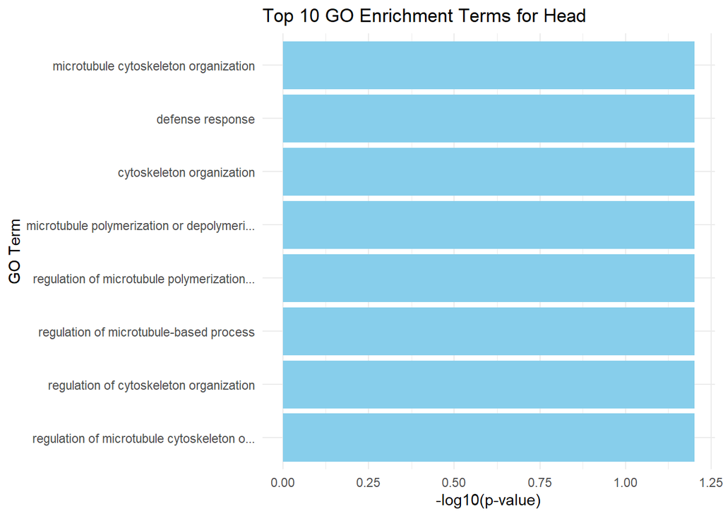

```r
      # Generate results table for significant GO terms
      table_head_BP <- GenTable(GOdata_head_BP, classicFisher = resultFis_head_BP, orderBy = "classicFisher", topNodes = length(usedGO(GOdata_head_BP)))

      # Filter for significant GO terms
      BP_sig_head <- subset(table_head_BP, classicFisher < 0.1)

      # Plot top 10 GO terms for head
      if (nrow(BP_sig_head) > 0) {
        BP_sig_head <- BP_sig_head[order(BP_sig_head$classicFisher), ]
        top_GO_head <- head(BP_sig_head, 10)
        top_GO_head$Term <- factor(top_GO_head$Term, levels = rev(top_GO_head$Term))
        top_GO_head$classicFisher <- as.numeric(as.character(top_GO_head$classicFisher))

        # Plot bar plot
        ggplot(top_GO_head, aes(x = Term, y = -log10(classicFisher))) +
          geom_bar(stat = "identity", fill = "skyblue") +
          coord_flip() +
          labs(title = "Top 10 GO Enrichment Terms for Head",
               x = "GO Term",
               y = "-log10(p-value)") +
          theme_minimal()
      }
```

In total, 14863 out of 20226 genes from the dataset are annotated in the GFF file.

Amongst the 1018 differentially expressed genes from the GLMM (glmmSeq) for head tissue (line = 186, conditioned = 904, and experience = 38, combined), 937 of them are annotated in the gff file.

I had to relieve the p-value from classicFisher to <0.1, because for head tissue, none of the genes showed a p-value below 0.05. However, except for the GO term associated with defense mechanisms, the other 7 GO terms are associated to functions (cytoskeleton organization and microtubule regulation/organization), that contribute in the morphological development of the parasitoid wasps.

## Ovary tissue

```r
      setwd("C:/Users/nanda/Desktop/Master Thesis")

      # Manually load the files for ovaries tissue
      ovaries_conditioned <- read.csv("ovaries_conditioned.csv", stringsAsFactors = FALSE)
      ovaries_experience <- read.csv("ovaries_experience.csv", stringsAsFactors = FALSE)
      ovaries_line <- read.csv("ovaries_line.csv", stringsAsFactors = FALSE)

      # Combine the ovaries files
      combined_ovaries <- bind_rows(ovaries_conditioned, ovaries_experience, ovaries_line)

      # Check the number of genes in combined ovaries data
      nrow(combined_ovaries)
```

```
## [1] 195
```

```r
      # Get unique genes for ovaries tissue
      counts_genes_ovaries <- unique(combined_ovaries$Gene)

      # Now load the GFF3 data (assuming it's the same)
      gff_data <- read_delim("GO_annotations.txt", delim = "\t", comment = "#", col_names = FALSE)
```

```r
      # Rename columns for GFF3 data
      colnames(gff_data) <- c("seqid", "source", "type", "start", "end", "score", "strand", "phase", "attributes")

      # Extract gene IDs (before "-") for matching with ovaries genes
      gff_data <- gff_data %>%
        mutate(GenePrefix = str_extract(seqid, "^[^\\-]+"))

      # Get unique gene prefixes
      gff_genes <- unique(gff_data$GenePrefix)

      # Find overlapping genes between ovaries genes and GFF3 data
      common_genes_ovaries <- intersect(toupper(counts_genes_ovaries), toupper(gff_genes))

      # Create gene list for topGO
      geneList_ovaries <- factor(as.integer(toupper(gff_genes) %in% toupper(counts_genes_ovaries)), levels = c(0, 1))
      names(geneList_ovaries) <- gff_genes

      # Check the gene list
      table(geneList_ovaries)
## geneList_ovaries
##     0     1
## 14794    69


# GO Enrichment
      # Prepare gene-to-GO mapping
      gff_data <- gff_data %>%
        mutate(GO_terms = str_extract(attributes, "GO:[^;]+")) %>%
        filter(!is.na(GO_terms))

      gene2go <- gff_data %>%
        group_by(GenePrefix) %>%
        summarise(GO = paste(unique(GO_terms), collapse = ", ")) %>%
        deframe()

      # Create topGO data object for ovaries tissue (Biological Process)
      GOdata_ovaries_BP <- new("topGOdata",
                               ontology = "BP",
                               allGenes = geneList_ovaries,
                               annot = annFUN.gene2GO,
                               gene2GO = gene2go)
```

```
##
## Building most specific GOs .....
##  ( 73 GO terms found. )
##
## Build GO DAG topology ..........
##  ( 409 GO terms and 816 relations. )
##
## Annotating nodes ...............
##  ( 191 genes annotated to the GO terms. )
```

```r
      # Run GO enrichment test
      resultFis_ovaries_BP <- runTest(GOdata_ovaries_BP, algorithm = "classic", statistic = "fisher")
```

```
##
##           -- Classic Algorithm --
##
##       the algorithm is scoring 14 nontrivial nodes
##       parameters:
##           test statistic: fisher
```

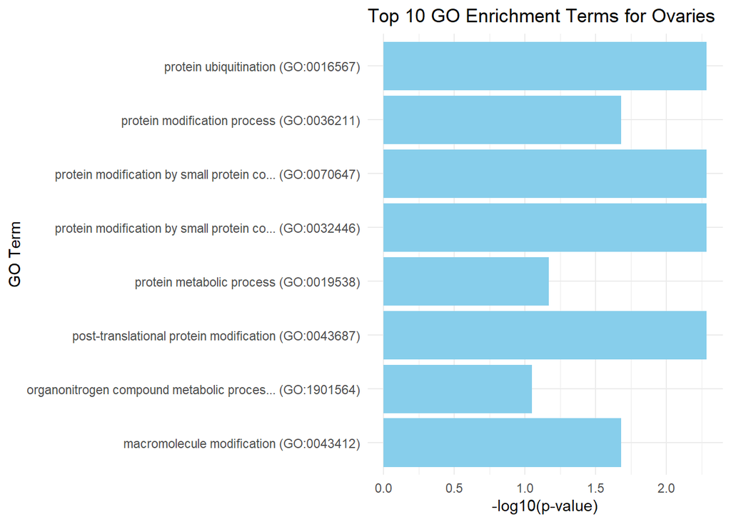

```r
      # Generate results table for significant GO terms
      table_ovaries_BP <- GenTable(GOdata_ovaries_BP, classicFisher = resultFis_ovaries_BP, orderBy = "classicFisher", topNodes = length(usedGO(GOdata_ovaries_BP)))

      # Filter for significant GO terms
      BP_sig_ovaries <- subset(table_ovaries_BP, classicFisher < 0.1)

      # Make the GO terms unique by appending GO ID to the term
      BP_sig_ovaries$Term <- paste(BP_sig_ovaries$Term, BP_sig_ovaries$GO.ID, sep = " (")

      # Now ensure it closes the parentheses
      BP_sig_ovaries$Term <- paste0(BP_sig_ovaries$Term, ")")

      # Plot top 10 GO terms for ovaries
      if (nrow(BP_sig_ovaries) > 0) {
        BP_sig_ovaries <- BP_sig_ovaries[order(BP_sig_ovaries$classicFisher), ]
        top_GO_ovaries <- head(BP_sig_ovaries, 10)

        # Convert classicFisher to numeric
        top_GO_ovaries$classicFisher <- as.numeric(as.character(top_GO_ovaries$classicFisher))

        # Plot bar plot
        ggplot(top_GO_ovaries, aes(x = Term, y = -log10(classicFisher))) +
          geom_bar(stat = "identity", fill = "skyblue") +
          coord_flip() +
          labs(title = "Top 10 GO Enrichment Terms for Ovaries",
               x = "GO Term",
               y = "-log10(p-value)") +
          theme_minimal()
      }
```

Out of the 195 significantly differentially expressed genes from the ovaries GLMM, 69 were labelled as interesting by topGO, or annotated in the GFF file.

Again, we only have 8 significant or nearly GO terms. In this case, all GO terms except for those two associated to “protein metabolic processes” (p = 0.0681) and “organonitrogen compound metabolic processes” (p = 0.0890) are significant. All GO terms are associated to the synthesis of macromolecules such as proteins. Further insights into the actual function of these genes may give insight to the role of these genes towards host adaptation (synthesis of proteinbased toxins).

## Venom gland tissue

```r
setwd("C:/Users/nanda/Desktop/Master Thesis")

       # Manually load the files for venom glands
      venom_conditioned <- read.csv("venom_conditioned.csv", stringsAsFactors = FALSE)
      venom_experience <- read.csv("venom_experience.csv", stringsAsFactors = FALSE)
      venom_line <- read.csv("venom_line.csv", stringsAsFactors = FALSE)

      # Combine the venom glands files
      combined_venom <- bind_rows(venom_conditioned, venom_experience, venom_line)

      # Check the number of genes in combined venom data
      nrow(combined_venom)
```

```
## [1] 475
```

```r
      # Get unique genes for venom glands
      counts_genes_venom <- unique(combined_venom$Gene)

      # Now load the GFF3 data if not already loaded (skip if already loaded)
      # gff_data <- read_delim("GO_annotations.txt", delim = "\t", comment = "#", col_names = FALSE)

      # Rename columns for GFF3 data if not already renamed
      # colnames(gff_data) <- c("seqid", "source", "type", "start", "end", "score", "strand", "phase", "attributes")

      # Extract gene IDs (before "-") for matching with venom genes
      gff_data <- gff_data %>%
        mutate(GenePrefix = str_extract(seqid, "^[^\\-]+"))

      # Get unique gene prefixes
      gff_genes <- unique(gff_data$GenePrefix)

      # Find overlapping genes between venom genes and GFF3 data
      common_genes_venom <- intersect(toupper(counts_genes_venom), toupper(gff_genes))

      # Create gene list for topGO
      geneList_venom <- factor(as.integer(toupper(gff_genes) %in% toupper(counts_genes_venom)), levels = c(0, 1))
      names(geneList_venom) <- gff_genes

      # Check the gene list
      table(geneList_venom)
## geneList_venom
##    0    1
## 8605  112


#GO enrichment
      # Prepare gene-to-GO mapping (if not done already)
      gff_data <- gff_data %>%
        mutate(GO_terms = str_extract(attributes, "GO:[^;]+")) %>%
        filter(!is.na(GO_terms))

      gene2go <- gff_data %>%
        group_by(GenePrefix) %>%
        summarise(GO = paste(unique(GO_terms), collapse = ", ")) %>%
        deframe()

      # Create topGO data object for venom glands (Biological Process)
      GOdata_venom_BP <- new("topGOdata",
                             ontology = "BP",
                             allGenes = geneList_venom,
                             annot = annFUN.gene2GO,
                             gene2GO = gene2go)
```

```
##
## Building most specific GOs .....
##  ( 73 GO terms found. )
##
## Build GO DAG topology ..........
##  ( 409 GO terms and 816 relations. )
##
## Annotating nodes ...............
##  ( 191 genes annotated to the GO terms. )
```

```r
      # Run GO enrichment test
      resultFis_venom_BP <- runTest(GOdata_venom_BP, algorithm = "classic", statistic = "fisher")
```

```
##
##           -- Classic Algorithm --
##
##       the algorithm is scoring 26 nontrivial nodes
##       parameters:
##           test statistic: fisher
```

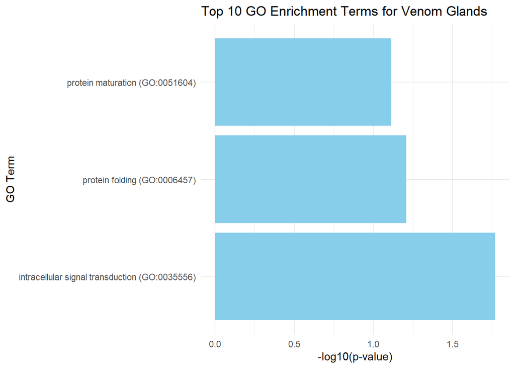

```r
      # Generate results table for significant GO terms
      table_venom_BP <- GenTable(GOdata_venom_BP, classicFisher = resultFis_venom_BP, orderBy = "classicFisher", topNodes = length(usedGO(GOdata_venom_BP)))

      # Filter for significant GO terms
      BP_sig_venom <- subset(table_venom_BP, classicFisher < 0.1)


      # Plot top 10 GO terms for venom glands
      if (nrow(BP_sig_venom) > 0) {
        BP_sig_venom <- BP_sig_venom[order(BP_sig_venom$classicFisher), ]
        top_GO_venom <- head(BP_sig_venom, 10)

        # Convert classicFisher to numeric
        top_GO_venom$classicFisher <- as.numeric(as.character(top_GO_venom$classicFisher))

        # Make the GO terms unique by appending GO.ID to avoid duplication error
        top_GO_venom$Term <- paste(top_GO_venom$Term, top_GO_venom$GO.ID, sep = " (")
        top_GO_venom$Term <- paste0(top_GO_venom$Term, ")")

        # Create the bar plot
        ggplot(top_GO_venom, aes(x = Term, y = -log10(classicFisher))) +
          geom_bar(stat = "identity", fill = "skyblue") +
          coord_flip() +
          labs(title = "Top 10 GO Enrichment Terms for Venom Glands",
               x = "GO Term",
               y = "-log10(p-value)") +
          theme_minimal()
      }
```

Out of the 475 significantly differentially expressed genes from the GLMM for venom glands, 112 were labelled as interesting by topGO.

The only significant GO term is associated to intracellular signal transduction (GO:0035556) (p = 0.017), The GO terms for protein folding (GO:0006457) (p = 0.062), and protein maturation (GO:0051604) (p = 0.077) are only nearly significant.

## GO enrichment for each subtreatment x tissue type

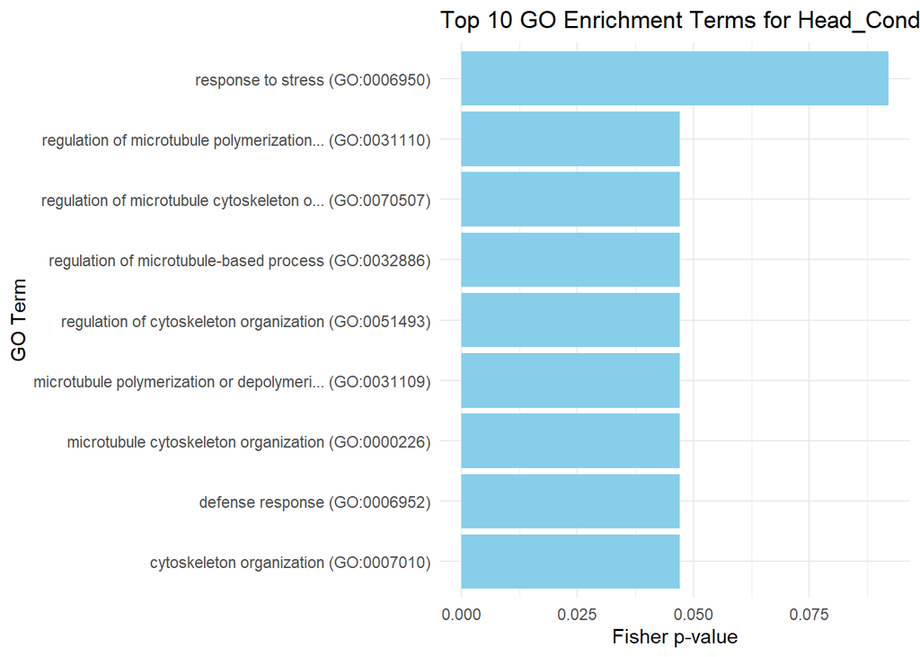

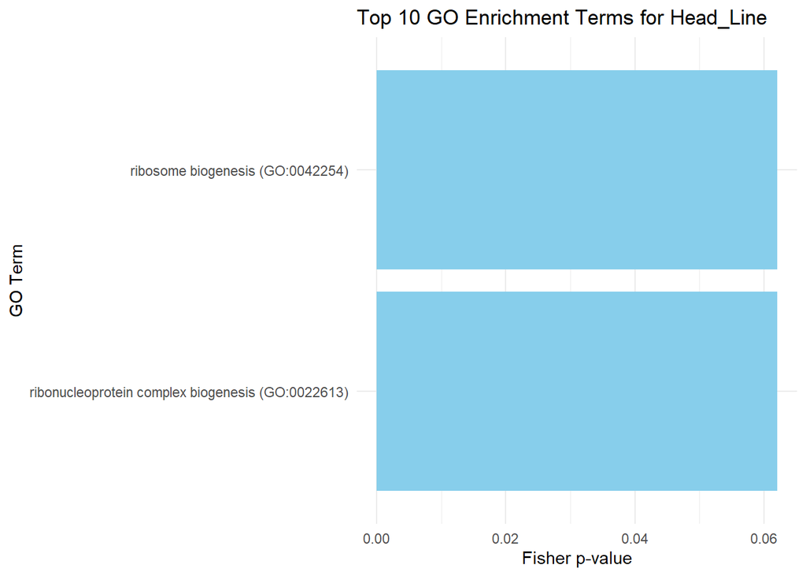

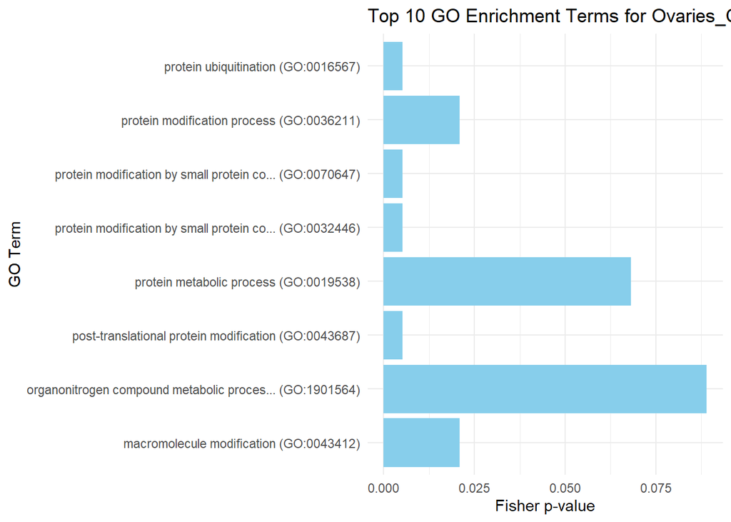

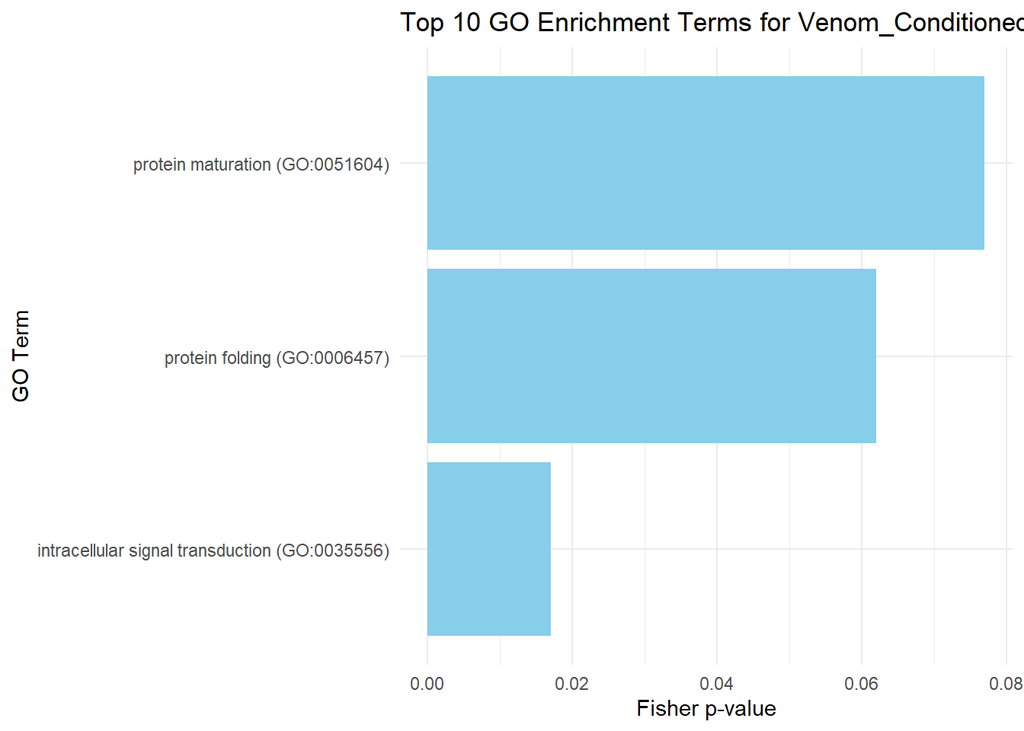

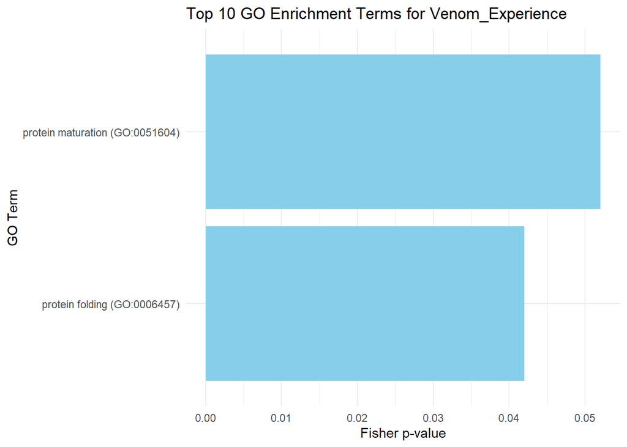

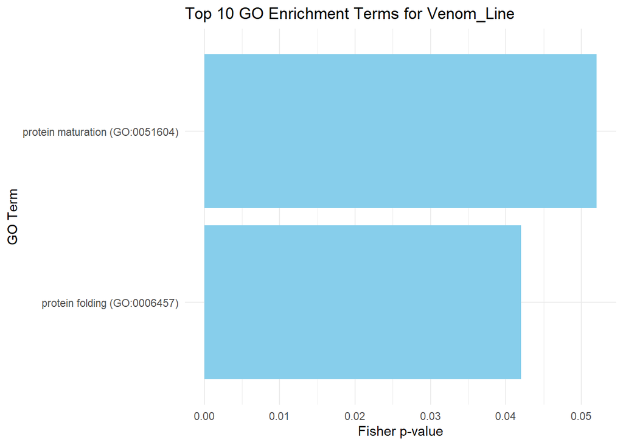

```r
setwd("C:/Users/nanda/Desktop/Master Thesis")

# GO enrichment for every subtreatment x tissue

# Function to perform GO enrichment and create a plot with raw p-values
perform_GO_enrichment_and_plot <- function(dataset_name, counts_genes, gff_genes, gene2go) {
  # Find overlapping genes between dataset genes and GFF3 data
  common_genes <- intersect(toupper(counts_genes), toupper(gff_genes))
  cat("Number of overlapping genes for", dataset_name, ":", length(common_genes), "\n")

  # Create gene list for topGO
  geneList <- factor(as.integer(toupper(gff_genes) %in% toupper(counts_genes)), levels = c(0, 1))
  names(geneList) <- gff_genes

  # Create topGO data object (Biological Process)
  GOdata <- new("topGOdata",
                ontology = "BP",
                allGenes = geneList,
                annot = annFUN.gene2GO,
                gene2GO = gene2go)

  # Run GO enrichment test
  resultFis <- runTest(GOdata, algorithm = "classic", statistic = "fisher")

  # Generate results table for GO terms
  table_BP <- GenTable(GOdata, classicFisher = resultFis, orderBy = "classicFisher", topNodes = length(usedGO(GOdata)))

  # Filter for significant GO terms (classicFisher < 0.1)
  BP_sig <- subset(table_BP, classicFisher < 0.1)

  # Plot top 10 GO terms if available
  plot <- NULL
  if (nrow(BP_sig) > 0) {
    BP_sig <- BP_sig[order(BP_sig$classicFisher), ]
    top_GO <- head(BP_sig, 10)

    # Convert classicFisher to numeric
    top_GO$classicFisher <- as.numeric(as.character(top_GO$classicFisher))

    # Make the GO terms unique by appending GO.ID to avoid duplication error
    top_GO$Term <- paste(top_GO$Term, top_GO$GO.ID, sep = " (")
    top_GO$Term <- paste0(top_GO$Term, ")")

    # Create the bar plot
    plot <- ggplot(top_GO, aes(x = Term, y = classicFisher)) +
      geom_bar(stat = "identity", fill = "skyblue") +
      coord_flip() +
      labs(title = paste("Top 10 GO Enrichment Terms for", dataset_name),
           x = "GO Term",
           y = "Fisher p-value") +
      theme_minimal()
  } else {
    cat("No significant GO terms for", dataset_name, "\n")
  }

  # Return the full table, significant table, and plot
  return(list(full_table = table_BP, significant_genes = BP_sig, plot = plot))
}

# Load the GFF3 data
gff_data <- read_delim("GO_annotations.txt", delim = "\t", comment = "#", col_names = FALSE)

# Rename columns for GFF3 data
colnames(gff_data) <- c("seqid", "source", "type", "start", "end", "score", "strand", "phase", "attributes")

# Extract gene IDs (before "-") for matching with tissue-specific genes
gff_data <- gff_data %>%
  mutate(GenePrefix = str_extract(seqid, "^[^\\-]+"))

# Get unique gene prefixes
gff_genes <- unique(gff_data$GenePrefix)

# Prepare gene-to-GO mapping
gff_data <- gff_data %>%
  mutate(GO_terms = str_extract(attributes, "GO:[^;]+")) %>%
  filter(!is.na(GO_terms))

gene2go <- gff_data %>%
  group_by(GenePrefix) %>%
  summarise(GO = paste(unique(GO_terms), collapse = ", ")) %>%
  deframe()

### HEAD TISSUE ###
head_conditioned <- read.csv("head_conditioned.csv", stringsAsFactors = FALSE)
head_experience <- read.csv("head_experience.csv", stringsAsFactors = FALSE)
head_line <- read.csv("head_line.csv", stringsAsFactors = FALSE)

# Create individual plots for each dataset
head_conditioned_results <- perform_GO_enrichment_and_plot("Head_Conditioned", unique(head_conditioned$Gene), gff_genes, gene2go)
## Number of overlapping genes for Head_Conditioned : 827
head_experience_results <- perform_GO_enrichment_and_plot("Head_Experience", unique(head_experience$Gene), gff_genes, gene2go)
## Number of overlapping genes for Head_Experience : 26
## No significant GO terms for Head_Experience
head_line_results <- perform_GO_enrichment_and_plot("Head_Line", unique(head_line$Gene), gff_genes, gene2go)
## Number of overlapping genes for Head_Line : 167

# Print plots
if (!is.null(head_conditioned_results$plot)) print(head_conditioned_results$plot)
if (!is.null(head_experience_results$plot)) print(head_experience_results$plot)
if (!is.null(head_line_results$plot)) print(head_line_results$plot)

# Save results to CSV
write.csv(head_conditioned_results$full_table, "Head_Conditioned_Full_GO_Enrichment.csv", row.names = FALSE)
write.csv(head_conditioned_results$significant_genes, "Head_Conditioned_Significant_GO_Enrichment.csv", row.names = FALSE)

write.csv(head_experience_results$full_table, "Head_Experience_Full_GO_Enrichment.csv", row.names = FALSE)
write.csv(head_experience_results$significant_genes, "Head_Experience_Significant_GO_Enrichment.csv", row.names = FALSE)

write.csv(head_line_results$full_table, "Head_Line_Full_GO_Enrichment.csv", row.names = FALSE)
write.csv(head_line_results$significant_genes, "Head_Line_Significant_GO_Enrichment.csv", row.names = FALSE)

### OVARIES TISSUE ###
ovaries_conditioned <- read.csv("ovaries_conditioned.csv", stringsAsFactors = FALSE)
ovaries_experience <- read.csv("ovaries_experience.csv", stringsAsFactors = FALSE)
ovaries_line <- read.csv("ovaries_line.csv", stringsAsFactors = FALSE)

# Create individual plots for each dataset
ovaries_conditioned_results <- perform_GO_enrichment_and_plot("Ovaries_Conditioned", unique(ovaries_conditioned$Gene), gff_genes, gene2go)
## Number of overlapping genes for Ovaries_Conditioned : 63
ovaries_experience_results <- perform_GO_enrichment_and_plot("Ovaries_Experience", unique(ovaries_experience$Gene), gff_genes, gene2go)
## Number of overlapping genes for Ovaries_Experience : 41
## No significant GO terms for Ovaries_Experience
ovaries_line_results <- perform_GO_enrichment_and_plot("Ovaries_Line", unique(ovaries_line$Gene), gff_genes, gene2go)
## Number of overlapping genes for Ovaries_Line : 39
## No significant GO terms for Ovaries_Line

# Print plots
if (!is.null(ovaries_conditioned_results$plot)) print(ovaries_conditioned_results$plot)
if (!is.null(ovaries_experience_results$plot)) print(ovaries_experience_results$plot)
if (!is.null(ovaries_line_results$plot)) print(ovaries_line_results$plot)

# Save results to CSV
write.csv(ovaries_conditioned_results$full_table, "Ovaries_Conditioned_Full_GO_Enrichment.csv", row.names = FALSE)
write.csv(ovaries_conditioned_results$significant_genes, "Ovaries_Conditioned_Significant_GO_Enrichment.csv", row.names = FALSE)

write.csv(ovaries_experience_results$full_table, "Ovaries_Experience_Full_GO_Enrichment.csv", row.names = FALSE)
write.csv(ovaries_experience_results$significant_genes, "Ovaries_Experience_Significant_GO_Enrichment.csv", row.names = FALSE)

write.csv(ovaries_line_results$full_table, "Ovaries_Line_Full_GO_Enrichment.csv", row.names = FALSE)
write.csv(ovaries_line_results$significant_genes, "Ovaries_Line_Significant_GO_Enrichment.csv", row.names = FALSE)

### VENOM GLANDS TISSUE ###
venom_conditioned <- read.csv("venom_conditioned.csv", stringsAsFactors = FALSE)
venom_experience <- read.csv("venom_experience.csv", stringsAsFactors = FALSE)
venom_line <- read.csv("venom_line.csv", stringsAsFactors = FALSE)

# Create individual plots for each dataset
venom_conditioned_results <- perform_GO_enrichment_and_plot("Venom_Conditioned", unique(venom_conditioned$Gene), gff_genes, gene2go)
## Number of overlapping genes for Venom_Conditioned : 162
venom_experience_results <- perform_GO_enrichment_and_plot("Venom_Experience", unique(venom_experience$Gene), gff_genes, gene2go)
## Number of overlapping genes for Venom_Experience : 114
venom_line_results <- perform_GO_enrichment_and_plot("Venom_Line", unique(venom_line$Gene), gff_genes, gene2go)
## Number of overlapping genes for Venom_Line : 138

# Print plots
if (!is.null(venom_conditioned_results$plot)) print(venom_conditioned_results$plot)
if (!is.null(venom_experience_results$plot)) print(venom_experience_results$plot)
if (!is.null(venom_line_results$plot)) print(venom_line_results$plot)

# Save results to CSV
write.csv(venom_conditioned_results$full_table, "Venom_Conditioned_Full_GO_Enrichment.csv", row.names = FALSE)
write.csv(venom_conditioned_results$significant_genes, "Venom_Conditioned_Significant_GO_Enrichment.csv", row.names = FALSE)

write.csv(venom_experience_results$full_table, "Venom_Experience_Full_GO_Enrichment.csv", row.names = FALSE)
write.csv(venom_experience_results$significant_genes, "Venom_Experience_Significant_GO_Enrichment.csv", row.names = FALSE)

write.csv(venom_line_results$full_table, "Venom_Line_Full_GO_Enrichment.csv", row.names = FALSE)
write.csv(venom_line_results$significant_genes, "Venom_Line_Significant_GO_Enrichment.csv", row.names = FALSE)
```

## Overall GO enrichment results

The following tables show the overall GO enrichment results, including non-significant GO terms. The overall tables (e.g. Head - Overall BP Results) are the results of the GO enrichment analyses with all sub-treatments (Line, Conditioned, Experience) combined into one dataframe (to create an overall list of significant genes per tissue type).

**Venom - Line Results**

| GO.ID | Term | Annotated | Significant | Expected | classicFisher |
| --- | --- | --- | --- | --- | --- |
| GO:0006457 | protein folding | 4 | 1 | 0.04 | 0.042 |
| GO:0051604 | protein maturation | 5 | 1 | 0.05 | 0.052 |
| GO:0019538 | protein metabolic process | 13 | 1 | 0.14 | 0.132 |
| GO:0035556 | intracellular signal transduction | 15 | 1 | 0.16 | 0.151 |
| GO:1901564 | organonitrogen compound metabolic proces… | 17 | 1 | 0.18 | 0.171 |
| GO:0009059 | macromolecule biosynthetic process | 36 | 1 | 0.38 | 0.342 |
| GO:0010467 | gene expression | 36 | 1 | 0.38 | 0.342 |
| GO:0007165 | signal transduction | 41 | 1 | 0.43 | 0.384 |
| GO:0007154 | cell communication | 42 | 1 | 0.44 | 0.392 |
| GO:0051716 | cellular response to stimulus | 42 | 1 | 0.44 | 0.392 |
| GO:0050896 | response to stimulus | 43 | 1 | 0.45 | 0.400 |
| GO:0023052 | signaling | 45 | 1 | 0.47 | 0.417 |
| GO:0043170 | macromolecule metabolic process | 46 | 1 | 0.48 | 0.425 |
| GO:0006807 | nitrogen compound metabolic process | 52 | 1 | 0.54 | 0.471 |
| GO:0044249 | cellular biosynthetic process | 52 | 1 | 0.54 | 0.471 |
| GO:1901576 | organic substance biosynthetic process | 52 | 1 | 0.54 | 0.471 |
| GO:0009058 | biosynthetic process | 54 | 1 | 0.57 | 0.487 |
| GO:0050794 | regulation of cellular process | 63 | 1 | 0.66 | 0.552 |
| GO:0050789 | regulation of biological process | 67 | 1 | 0.70 | 0.580 |
| GO:0065007 | biological regulation | 68 | 1 | 0.71 | 0.586 |
| GO:0044237 | cellular metabolic process | 70 | 1 | 0.73 | 0.600 |
| GO:0009987 | cellular process | 153 | 2 | 1.60 | 0.641 |
| GO:0044238 | primary metabolic process | 77 | 1 | 0.81 | 0.645 |
| GO:0071704 | organic substance metabolic process | 80 | 1 | 0.84 | 0.664 |
| GO:0008152 | metabolic process | 91 | 1 | 0.95 | 0.727 |
| GO:0008150 | biological_process | 191 | 2 | 2.00 | 1.000 |
| GO:0000003 | reproduction | 1 | 0 | 0.01 | 1.000 |
| GO:0000070 | mitotic sister chromatid segregation | 2 | 0 | 0.02 | 1.000 |
| GO:0000075 | cell cycle checkpoint signaling | 2 | 0 | 0.02 | 1.000 |
| GO:0000184 | nuclear-transcribed mRNA catabolic proce… | 1 | 0 | 0.01 | 1.000 |

[output cut: 379 more lines]

**Venom - Conditioned Results**

| GO.ID | Term | Annotated | Significant | Expected | classicFisher |
| --- | --- | --- | --- | --- | --- |
| GO:0035556 | intracellular signal transduction | 15 | 2 | 0.24 | 0.017 |
| GO:0006457 | protein folding | 4 | 1 | 0.06 | 0.062 |
| GO:0051604 | protein maturation | 5 | 1 | 0.08 | 0.077 |
| GO:0007165 | signal transduction | 41 | 2 | 0.64 | 0.117 |
| GO:0007154 | cell communication | 42 | 2 | 0.66 | 0.122 |
| GO:0051716 | cellular response to stimulus | 42 | 2 | 0.66 | 0.122 |
| GO:0050896 | response to stimulus | 43 | 2 | 0.68 | 0.128 |
| GO:0023052 | signaling | 45 | 2 | 0.71 | 0.139 |
| GO:0019538 | protein metabolic process | 13 | 1 | 0.20 | 0.192 |
| GO:1901564 | organonitrogen compound metabolic proces… | 17 | 1 | 0.27 | 0.245 |
| GO:0050794 | regulation of cellular process | 63 | 2 | 0.99 | 0.253 |
| GO:0050789 | regulation of biological process | 67 | 2 | 1.05 | 0.282 |
| GO:0065007 | biological regulation | 68 | 2 | 1.07 | 0.289 |
| GO:0009059 | macromolecule biosynthetic process | 36 | 1 | 0.57 | 0.468 |
| GO:0010467 | gene expression | 36 | 1 | 0.57 | 0.468 |
| GO:0009987 | cellular process | 153 | 3 | 2.40 | 0.512 |
| GO:0043170 | macromolecule metabolic process | 46 | 1 | 0.72 | 0.565 |
| GO:0006807 | nitrogen compound metabolic process | 52 | 1 | 0.82 | 0.617 |
| GO:0044249 | cellular biosynthetic process | 52 | 1 | 0.82 | 0.617 |
| GO:1901576 | organic substance biosynthetic process | 52 | 1 | 0.82 | 0.617 |
| GO:0009058 | biosynthetic process | 54 | 1 | 0.85 | 0.633 |
| GO:0044237 | cellular metabolic process | 70 | 1 | 1.10 | 0.748 |
| GO:0044238 | primary metabolic process | 77 | 1 | 1.21 | 0.790 |
| GO:0071704 | organic substance metabolic process | 80 | 1 | 1.26 | 0.806 |
| GO:0008152 | metabolic process | 91 | 1 | 1.43 | 0.859 |
| GO:0008150 | biological_process | 191 | 3 | 3.00 | 1.000 |
| GO:0000003 | reproduction | 1 | 0 | 0.02 | 1.000 |
| GO:0000070 | mitotic sister chromatid segregation | 2 | 0 | 0.03 | 1.000 |
| GO:0000075 | cell cycle checkpoint signaling | 2 | 0 | 0.03 | 1.000 |
| GO:0000184 | nuclear-transcribed mRNA catabolic proce… | 1 | 0 | 0.02 | 1.000 |

[output cut: 379 more lines]

**Venom - Experience Results**

| GO.ID | Term | Annotated | Significant | Expected | classicFisher |
| --- | --- | --- | --- | --- | --- |
| GO:0006457 | protein folding | 4 | 1 | 0.04 | 0.042 |
| GO:0051604 | protein maturation | 5 | 1 | 0.05 | 0.052 |
| GO:0019538 | protein metabolic process | 13 | 1 | 0.14 | 0.132 |
| GO:0035556 | intracellular signal transduction | 15 | 1 | 0.16 | 0.151 |
| GO:1901564 | organonitrogen compound metabolic proces… | 17 | 1 | 0.18 | 0.171 |
| GO:0009059 | macromolecule biosynthetic process | 36 | 1 | 0.38 | 0.342 |
| GO:0010467 | gene expression | 36 | 1 | 0.38 | 0.342 |
| GO:0007165 | signal transduction | 41 | 1 | 0.43 | 0.384 |
| GO:0007154 | cell communication | 42 | 1 | 0.44 | 0.392 |
| GO:0051716 | cellular response to stimulus | 42 | 1 | 0.44 | 0.392 |
| GO:0050896 | response to stimulus | 43 | 1 | 0.45 | 0.400 |
| GO:0023052 | signaling | 45 | 1 | 0.47 | 0.417 |
| GO:0043170 | macromolecule metabolic process | 46 | 1 | 0.48 | 0.425 |
| GO:0006807 | nitrogen compound metabolic process | 52 | 1 | 0.54 | 0.471 |
| GO:0044249 | cellular biosynthetic process | 52 | 1 | 0.54 | 0.471 |
| GO:1901576 | organic substance biosynthetic process | 52 | 1 | 0.54 | 0.471 |
| GO:0009058 | biosynthetic process | 54 | 1 | 0.57 | 0.487 |
| GO:0050794 | regulation of cellular process | 63 | 1 | 0.66 | 0.552 |
| GO:0050789 | regulation of biological process | 67 | 1 | 0.70 | 0.580 |
| GO:0065007 | biological regulation | 68 | 1 | 0.71 | 0.586 |
| GO:0044237 | cellular metabolic process | 70 | 1 | 0.73 | 0.600 |
| GO:0009987 | cellular process | 153 | 2 | 1.60 | 0.641 |
| GO:0044238 | primary metabolic process | 77 | 1 | 0.81 | 0.645 |
| GO:0071704 | organic substance metabolic process | 80 | 1 | 0.84 | 0.664 |
| GO:0008152 | metabolic process | 91 | 1 | 0.95 | 0.727 |
| GO:0008150 | biological_process | 191 | 2 | 2.00 | 1.000 |
| GO:0000003 | reproduction | 1 | 0 | 0.01 | 1.000 |
| GO:0000070 | mitotic sister chromatid segregation | 2 | 0 | 0.02 | 1.000 |
| GO:0000075 | cell cycle checkpoint signaling | 2 | 0 | 0.02 | 1.000 |
| GO:0000184 | nuclear-transcribed mRNA catabolic proce… | 1 | 0 | 0.01 | 1.000 |

[output cut: 379 more lines]

**Head - Conditioned Results**

| GO.ID | Term | Annotated | Significant | Expected | classicFisher |
| --- | --- | --- | --- | --- | --- |
| GO:0000226 | microtubule cytoskeleton organization | 1 | 1 | 0.05 | 0.047 |
| GO:0006952 | defense response | 1 | 1 | 0.05 | 0.047 |
| GO:0007010 | cytoskeleton organization | 1 | 1 | 0.05 | 0.047 |
| GO:0031109 | microtubule polymerization or depolymeri… | 1 | 1 | 0.05 | 0.047 |
| GO:0031110 | regulation of microtubule polymerization… | 1 | 1 | 0.05 | 0.047 |
| GO:0032886 | regulation of microtubule-based process | 1 | 1 | 0.05 | 0.047 |
| GO:0051493 | regulation of cytoskeleton organization | 1 | 1 | 0.05 | 0.047 |
| GO:0070507 | regulation of microtubule cytoskeleton o… | 1 | 1 | 0.05 | 0.047 |
| GO:0006950 | response to stress | 2 | 1 | 0.09 | 0.092 |
| GO:0007017 | microtubule-based process | 3 | 1 | 0.14 | 0.135 |
| GO:0033043 | regulation of organelle organization | 3 | 1 | 0.14 | 0.135 |
| GO:0051128 | regulation of cellular component organiz… | 3 | 1 | 0.14 | 0.135 |
| GO:0007034 | vacuolar transport | 6 | 1 | 0.28 | 0.254 |
| GO:0006661 | phosphatidylinositol biosynthetic proces… | 7 | 1 | 0.33 | 0.291 |
| GO:0046854 | phosphatidylinositol phosphate biosynthe… | 7 | 1 | 0.33 | 0.291 |
| GO:0006996 | organelle organization | 8 | 1 | 0.38 | 0.325 |
| GO:0008654 | phospholipid biosynthetic process | 8 | 1 | 0.38 | 0.325 |
| GO:0045017 | glycerolipid biosynthetic process | 8 | 1 | 0.38 | 0.325 |
| GO:0046474 | glycerophospholipid biosynthetic process | 8 | 1 | 0.38 | 0.325 |
| GO:0090407 | organophosphate biosynthetic process | 8 | 1 | 0.38 | 0.325 |
| GO:0050896 | response to stimulus | 43 | 3 | 2.03 | 0.328 |
| GO:0050794 | regulation of cellular process | 63 | 4 | 2.97 | 0.339 |
| GO:0006629 | lipid metabolic process | 27 | 2 | 1.27 | 0.372 |
| GO:0016043 | cellular component organization | 10 | 1 | 0.47 | 0.390 |
| GO:0046488 | phosphatidylinositol metabolic process | 10 | 1 | 0.47 | 0.390 |
| GO:0006810 | transport | 28 | 2 | 1.32 | 0.390 |
| GO:0050789 | regulation of biological process | 67 | 4 | 3.16 | 0.392 |
| GO:0065007 | biological regulation | 68 | 4 | 3.20 | 0.405 |
| GO:0051179 | localization | 29 | 2 | 1.37 | 0.409 |
| GO:0051234 | establishment of localization | 29 | 2 | 1.37 | 0.409 |

[output cut: 379 more lines]

**Head - Experience Results**

| GO.ID | Term | Annotated | Significant | Expected | classicFisher |
| --- | --- | --- | --- | --- | --- |
| GO:0000003 | reproduction | 1 | 0 | 0 | 1 |
| GO:0000070 | mitotic sister chromatid segregation | 2 | 0 | 0 | 1 |
| GO:0000075 | cell cycle checkpoint signaling | 2 | 0 | 0 | 1 |
| GO:0000184 | nuclear-transcribed mRNA catabolic proce… | 1 | 0 | 0 | 1 |
| GO:0000226 | microtubule cytoskeleton organization | 1 | 0 | 0 | 1 |
| GO:0000255 | allantoin metabolic process | 1 | 0 | 0 | 1 |
| GO:0000278 | mitotic cell cycle | 2 | 0 | 0 | 1 |
| GO:0000280 | nuclear division | 2 | 0 | 0 | 1 |
| GO:0000375 | RNA splicing, via transesterification re… | 1 | 0 | 0 | 1 |
| GO:0000377 | RNA splicing, via transesterification re… | 1 | 0 | 0 | 1 |
| GO:0000398 | mRNA splicing, via spliceosome | 1 | 0 | 0 | 1 |
| GO:0000819 | sister chromatid segregation | 2 | 0 | 0 | 1 |
| GO:0000956 | nuclear-transcribed mRNA catabolic proce… | 1 | 0 | 0 | 1 |
| GO:0001765 | membrane raft assembly | 1 | 0 | 0 | 1 |
| GO:0003006 | developmental process involved in reprod… | 1 | 0 | 0 | 1 |
| GO:0005975 | carbohydrate metabolic process | 1 | 0 | 0 | 1 |
| GO:0006082 | organic acid metabolic process | 1 | 0 | 0 | 1 |
| GO:0006139 | nucleobase-containing compound metabolic… | 36 | 0 | 0 | 1 |
| GO:0006259 | DNA metabolic process | 3 | 0 | 0 | 1 |
| GO:0006260 | DNA replication | 2 | 0 | 0 | 1 |
| GO:0006261 | DNA-templated DNA replication | 1 | 0 | 0 | 1 |
| GO:0006270 | DNA replication initiation | 1 | 0 | 0 | 1 |
| GO:0006275 | regulation of DNA replication | 1 | 0 | 0 | 1 |
| GO:0006281 | DNA repair | 1 | 0 | 0 | 1 |
| GO:0006351 | DNA-templated transcription | 16 | 0 | 0 | 1 |
| GO:0006352 | DNA-templated transcription initiation | 1 | 0 | 0 | 1 |
| GO:0006355 | regulation of DNA-templated transcriptio… | 14 | 0 | 0 | 1 |
| GO:0006359 | regulation of transcription by RNA polym… | 1 | 0 | 0 | 1 |
| GO:0006364 | rRNA processing | 1 | 0 | 0 | 1 |
| GO:0006366 | transcription by RNA polymerase II | 1 | 0 | 0 | 1 |

[output cut: 379 more lines]

**Head - Line Results**

| GO.ID | Term | Annotated | Significant | Expected | classicFisher |
| --- | --- | --- | --- | --- | --- |
| GO:0022613 | ribonucleoprotein complex biogenesis | 4 | 1 | 0.06 | 0.062 |
| GO:0042254 | ribosome biogenesis | 4 | 1 | 0.06 | 0.062 |
| GO:0007165 | signal transduction | 41 | 2 | 0.64 | 0.117 |
| GO:0044085 | cellular component biogenesis | 8 | 1 | 0.13 | 0.121 |
| GO:0007154 | cell communication | 42 | 2 | 0.66 | 0.122 |
| GO:0051716 | cellular response to stimulus | 42 | 2 | 0.66 | 0.122 |
| GO:0050896 | response to stimulus | 43 | 2 | 0.68 | 0.128 |
| GO:0023052 | signaling | 45 | 2 | 0.71 | 0.139 |
| GO:0071840 | cellular component organization or bioge… | 14 | 1 | 0.22 | 0.205 |
| GO:0035556 | intracellular signal transduction | 15 | 1 | 0.24 | 0.219 |
| GO:0050794 | regulation of cellular process | 63 | 2 | 0.99 | 0.253 |
| GO:0050789 | regulation of biological process | 67 | 2 | 1.05 | 0.282 |
| GO:0065007 | biological regulation | 68 | 2 | 1.07 | 0.289 |
| GO:0009987 | cellular process | 153 | 3 | 2.40 | 0.512 |
| GO:0008150 | biological_process | 191 | 3 | 3.00 | 1.000 |
| GO:0000003 | reproduction | 1 | 0 | 0.02 | 1.000 |
| GO:0000070 | mitotic sister chromatid segregation | 2 | 0 | 0.03 | 1.000 |
| GO:0000075 | cell cycle checkpoint signaling | 2 | 0 | 0.03 | 1.000 |
| GO:0000184 | nuclear-transcribed mRNA catabolic proce… | 1 | 0 | 0.02 | 1.000 |
| GO:0000226 | microtubule cytoskeleton organization | 1 | 0 | 0.02 | 1.000 |
| GO:0000255 | allantoin metabolic process | 1 | 0 | 0.02 | 1.000 |
| GO:0000278 | mitotic cell cycle | 2 | 0 | 0.03 | 1.000 |
| GO:0000280 | nuclear division | 2 | 0 | 0.03 | 1.000 |
| GO:0000375 | RNA splicing, via transesterification re… | 1 | 0 | 0.02 | 1.000 |
| GO:0000377 | RNA splicing, via transesterification re… | 1 | 0 | 0.02 | 1.000 |
| GO:0000398 | mRNA splicing, via spliceosome | 1 | 0 | 0.02 | 1.000 |
| GO:0000819 | sister chromatid segregation | 2 | 0 | 0.03 | 1.000 |
| GO:0000956 | nuclear-transcribed mRNA catabolic proce… | 1 | 0 | 0.02 | 1.000 |
| GO:0001765 | membrane raft assembly | 1 | 0 | 0.02 | 1.000 |
| GO:0003006 | developmental process involved in reprod… | 1 | 0 | 0.02 | 1.000 |

[output cut: 379 more lines]

**Ovaries - Conditioned Results**

| GO.ID | Term | Annotated | Significant | Expected | classicFisher |
| --- | --- | --- | --- | --- | --- |
| GO:0016567 | protein ubiquitination | 1 | 1 | 0.01 | 0.0052 |
| GO:0032446 | protein modification by small protein co… | 1 | 1 | 0.01 | 0.0052 |
| GO:0043687 | post-translational protein modification | 1 | 1 | 0.01 | 0.0052 |
| GO:0070647 | protein modification by small protein co… | 1 | 1 | 0.01 | 0.0052 |
| GO:0036211 | protein modification process | 4 | 1 | 0.02 | 0.0209 |
| GO:0043412 | macromolecule modification | 4 | 1 | 0.02 | 0.0209 |
| GO:0019538 | protein metabolic process | 13 | 1 | 0.07 | 0.0681 |
| GO:1901564 | organonitrogen compound metabolic proces… | 17 | 1 | 0.09 | 0.0890 |
| GO:0043170 | macromolecule metabolic process | 46 | 1 | 0.24 | 0.2408 |
| GO:0006807 | nitrogen compound metabolic process | 52 | 1 | 0.27 | 0.2723 |
| GO:0044238 | primary metabolic process | 77 | 1 | 0.40 | 0.4031 |
| GO:0071704 | organic substance metabolic process | 80 | 1 | 0.42 | 0.4188 |
| GO:0008152 | metabolic process | 91 | 1 | 0.48 | 0.4764 |
| GO:0008150 | biological_process | 191 | 1 | 1.00 | 1.0000 |
| GO:0000003 | reproduction | 1 | 0 | 0.01 | 1.0000 |
| GO:0000070 | mitotic sister chromatid segregation | 2 | 0 | 0.01 | 1.0000 |
| GO:0000075 | cell cycle checkpoint signaling | 2 | 0 | 0.01 | 1.0000 |
| GO:0000184 | nuclear-transcribed mRNA catabolic proce… | 1 | 0 | 0.01 | 1.0000 |
| GO:0000226 | microtubule cytoskeleton organization | 1 | 0 | 0.01 | 1.0000 |
| GO:0000255 | allantoin metabolic process | 1 | 0 | 0.01 | 1.0000 |
| GO:0000278 | mitotic cell cycle | 2 | 0 | 0.01 | 1.0000 |
| GO:0000280 | nuclear division | 2 | 0 | 0.01 | 1.0000 |
| GO:0000375 | RNA splicing, via transesterification re… | 1 | 0 | 0.01 | 1.0000 |
| GO:0000377 | RNA splicing, via transesterification re… | 1 | 0 | 0.01 | 1.0000 |
| GO:0000398 | mRNA splicing, via spliceosome | 1 | 0 | 0.01 | 1.0000 |
| GO:0000819 | sister chromatid segregation | 2 | 0 | 0.01 | 1.0000 |
| GO:0000956 | nuclear-transcribed mRNA catabolic proce… | 1 | 0 | 0.01 | 1.0000 |
| GO:0001765 | membrane raft assembly | 1 | 0 | 0.01 | 1.0000 |
| GO:0003006 | developmental process involved in reprod… | 1 | 0 | 0.01 | 1.0000 |
| GO:0005975 | carbohydrate metabolic process | 1 | 0 | 0.01 | 1.0000 |

[output cut: 379 more lines]

**Ovaries - Experience Results**

| GO.ID | Term | Annotated | Significant | Expected | classicFisher |
| --- | --- | --- | --- | --- | --- |
| GO:0000003 | reproduction | 1 | 0 | 0 | 1 |
| GO:0000070 | mitotic sister chromatid segregation | 2 | 0 | 0 | 1 |
| GO:0000075 | cell cycle checkpoint signaling | 2 | 0 | 0 | 1 |
| GO:0000184 | nuclear-transcribed mRNA catabolic proce… | 1 | 0 | 0 | 1 |
| GO:0000226 | microtubule cytoskeleton organization | 1 | 0 | 0 | 1 |
| GO:0000255 | allantoin metabolic process | 1 | 0 | 0 | 1 |
| GO:0000278 | mitotic cell cycle | 2 | 0 | 0 | 1 |
| GO:0000280 | nuclear division | 2 | 0 | 0 | 1 |
| GO:0000375 | RNA splicing, via transesterification re… | 1 | 0 | 0 | 1 |
| GO:0000377 | RNA splicing, via transesterification re… | 1 | 0 | 0 | 1 |
| GO:0000398 | mRNA splicing, via spliceosome | 1 | 0 | 0 | 1 |
| GO:0000819 | sister chromatid segregation | 2 | 0 | 0 | 1 |
| GO:0000956 | nuclear-transcribed mRNA catabolic proce… | 1 | 0 | 0 | 1 |
| GO:0001765 | membrane raft assembly | 1 | 0 | 0 | 1 |
| GO:0003006 | developmental process involved in reprod… | 1 | 0 | 0 | 1 |
| GO:0005975 | carbohydrate metabolic process | 1 | 0 | 0 | 1 |
| GO:0006082 | organic acid metabolic process | 1 | 0 | 0 | 1 |
| GO:0006139 | nucleobase-containing compound metabolic… | 36 | 0 | 0 | 1 |
| GO:0006259 | DNA metabolic process | 3 | 0 | 0 | 1 |
| GO:0006260 | DNA replication | 2 | 0 | 0 | 1 |
| GO:0006261 | DNA-templated DNA replication | 1 | 0 | 0 | 1 |
| GO:0006270 | DNA replication initiation | 1 | 0 | 0 | 1 |
| GO:0006275 | regulation of DNA replication | 1 | 0 | 0 | 1 |
| GO:0006281 | DNA repair | 1 | 0 | 0 | 1 |
| GO:0006351 | DNA-templated transcription | 16 | 0 | 0 | 1 |
| GO:0006352 | DNA-templated transcription initiation | 1 | 0 | 0 | 1 |
| GO:0006355 | regulation of DNA-templated transcriptio… | 14 | 0 | 0 | 1 |
| GO:0006359 | regulation of transcription by RNA polym… | 1 | 0 | 0 | 1 |
| GO:0006364 | rRNA processing | 1 | 0 | 0 | 1 |
| GO:0006366 | transcription by RNA polymerase II | 1 | 0 | 0 | 1 |

[output cut: 379 more lines]

**Ovaries - Line Results**

| GO.ID | Term | Annotated | Significant | Expected | classicFisher |
| --- | --- | --- | --- | --- | --- |
| GO:0000003 | reproduction | 1 | 0 | 0 | 1 |
| GO:0000070 | mitotic sister chromatid segregation | 2 | 0 | 0 | 1 |
| GO:0000075 | cell cycle checkpoint signaling | 2 | 0 | 0 | 1 |
| GO:0000184 | nuclear-transcribed mRNA catabolic proce… | 1 | 0 | 0 | 1 |
| GO:0000226 | microtubule cytoskeleton organization | 1 | 0 | 0 | 1 |
| GO:0000255 | allantoin metabolic process | 1 | 0 | 0 | 1 |
| GO:0000278 | mitotic cell cycle | 2 | 0 | 0 | 1 |
| GO:0000280 | nuclear division | 2 | 0 | 0 | 1 |
| GO:0000375 | RNA splicing, via transesterification re… | 1 | 0 | 0 | 1 |
| GO:0000377 | RNA splicing, via transesterification re… | 1 | 0 | 0 | 1 |
| GO:0000398 | mRNA splicing, via spliceosome | 1 | 0 | 0 | 1 |
| GO:0000819 | sister chromatid segregation | 2 | 0 | 0 | 1 |
| GO:0000956 | nuclear-transcribed mRNA catabolic proce… | 1 | 0 | 0 | 1 |
| GO:0001765 | membrane raft assembly | 1 | 0 | 0 | 1 |
| GO:0003006 | developmental process involved in reprod… | 1 | 0 | 0 | 1 |
| GO:0005975 | carbohydrate metabolic process | 1 | 0 | 0 | 1 |
| GO:0006082 | organic acid metabolic process | 1 | 0 | 0 | 1 |
| GO:0006139 | nucleobase-containing compound metabolic… | 36 | 0 | 0 | 1 |
| GO:0006259 | DNA metabolic process | 3 | 0 | 0 | 1 |
| GO:0006260 | DNA replication | 2 | 0 | 0 | 1 |
| GO:0006261 | DNA-templated DNA replication | 1 | 0 | 0 | 1 |
| GO:0006270 | DNA replication initiation | 1 | 0 | 0 | 1 |
| GO:0006275 | regulation of DNA replication | 1 | 0 | 0 | 1 |
| GO:0006281 | DNA repair | 1 | 0 | 0 | 1 |
| GO:0006351 | DNA-templated transcription | 16 | 0 | 0 | 1 |
| GO:0006352 | DNA-templated transcription initiation | 1 | 0 | 0 | 1 |
| GO:0006355 | regulation of DNA-templated transcriptio… | 14 | 0 | 0 | 1 |
| GO:0006359 | regulation of transcription by RNA polym… | 1 | 0 | 0 | 1 |
| GO:0006364 | rRNA processing | 1 | 0 | 0 | 1 |
| GO:0006366 | transcription by RNA polymerase II | 1 | 0 | 0 | 1 |

[output cut: 379 more lines]

**Head - Overall BP Results**

| GO.ID | Term | Annotated | Significant | Expected | classicFisher |
| --- | --- | --- | --- | --- | --- |
| GO:0000226 | microtubule cytoskeleton organization | 1 | 1 | 0.06 | 0.063 |
| GO:0006952 | defense response | 1 | 1 | 0.06 | 0.063 |
| GO:0007010 | cytoskeleton organization | 1 | 1 | 0.06 | 0.063 |
| GO:0031109 | microtubule polymerization or depolymeri… | 1 | 1 | 0.06 | 0.063 |
| GO:0031110 | regulation of microtubule polymerization… | 1 | 1 | 0.06 | 0.063 |
| GO:0032886 | regulation of microtubule-based process | 1 | 1 | 0.06 | 0.063 |
| GO:0051493 | regulation of cytoskeleton organization | 1 | 1 | 0.06 | 0.063 |
| GO:0070507 | regulation of microtubule cytoskeleton o… | 1 | 1 | 0.06 | 0.063 |
| GO:0050896 | response to stimulus | 43 | 5 | 2.70 | 0.104 |
| GO:0006950 | response to stress | 2 | 1 | 0.13 | 0.122 |
| GO:0050794 | regulation of cellular process | 63 | 6 | 3.96 | 0.163 |
| GO:0007017 | microtubule-based process | 3 | 1 | 0.19 | 0.178 |
| GO:0033043 | regulation of organelle organization | 3 | 1 | 0.19 | 0.178 |
| GO:0051128 | regulation of cellular component organiz… | 3 | 1 | 0.19 | 0.178 |
| GO:0050789 | regulation of biological process | 67 | 6 | 4.21 | 0.208 |
| GO:0071840 | cellular component organization or bioge… | 14 | 2 | 0.88 | 0.216 |
| GO:0065007 | biological regulation | 68 | 6 | 4.27 | 0.219 |
| GO:0022613 | ribonucleoprotein complex biogenesis | 4 | 1 | 0.25 | 0.230 |
| GO:0042254 | ribosome biogenesis | 4 | 1 | 0.25 | 0.230 |
| GO:0035556 | intracellular signal transduction | 15 | 2 | 0.94 | 0.240 |
| GO:0007165 | signal transduction | 41 | 4 | 2.58 | 0.241 |
| GO:0007154 | cell communication | 42 | 4 | 2.64 | 0.256 |
| GO:0051716 | cellular response to stimulus | 42 | 4 | 2.64 | 0.256 |
| GO:0023052 | signaling | 45 | 4 | 2.83 | 0.304 |
| GO:0007034 | vacuolar transport | 6 | 1 | 0.38 | 0.326 |
| GO:0006661 | phosphatidylinositol biosynthetic proces… | 7 | 1 | 0.44 | 0.370 |
| GO:0046854 | phosphatidylinositol phosphate biosynthe… | 7 | 1 | 0.44 | 0.370 |
| GO:0006996 | organelle organization | 8 | 1 | 0.50 | 0.411 |
| GO:0008654 | phospholipid biosynthetic process | 8 | 1 | 0.50 | 0.411 |
| GO:0044085 | cellular component biogenesis | 8 | 1 | 0.50 | 0.411 |

[output cut: 379 more lines]

**Ovaries - Overall BP Results**

| GO.ID | Term | Annotated | Significant | Expected | classicFisher |
| --- | --- | --- | --- | --- | --- |
| GO:0016567 | protein ubiquitination | 1 | 1 | 0.01 | 0.0052 |
| GO:0032446 | protein modification by small protein co… | 1 | 1 | 0.01 | 0.0052 |
| GO:0043687 | post-translational protein modification | 1 | 1 | 0.01 | 0.0052 |
| GO:0070647 | protein modification by small protein co… | 1 | 1 | 0.01 | 0.0052 |
| GO:0036211 | protein modification process | 4 | 1 | 0.02 | 0.0209 |
| GO:0043412 | macromolecule modification | 4 | 1 | 0.02 | 0.0209 |
| GO:0019538 | protein metabolic process | 13 | 1 | 0.07 | 0.0681 |
| GO:1901564 | organonitrogen compound metabolic proces… | 17 | 1 | 0.09 | 0.0890 |
| GO:0043170 | macromolecule metabolic process | 46 | 1 | 0.24 | 0.2408 |
| GO:0006807 | nitrogen compound metabolic process | 52 | 1 | 0.27 | 0.2723 |
| GO:0044238 | primary metabolic process | 77 | 1 | 0.40 | 0.4031 |
| GO:0071704 | organic substance metabolic process | 80 | 1 | 0.42 | 0.4188 |
| GO:0008152 | metabolic process | 91 | 1 | 0.48 | 0.4764 |
| GO:0008150 | biological_process | 191 | 1 | 1.00 | 1.0000 |
| GO:0000003 | reproduction | 1 | 0 | 0.01 | 1.0000 |
| GO:0000070 | mitotic sister chromatid segregation | 2 | 0 | 0.01 | 1.0000 |
| GO:0000075 | cell cycle checkpoint signaling | 2 | 0 | 0.01 | 1.0000 |
| GO:0000184 | nuclear-transcribed mRNA catabolic proce… | 1 | 0 | 0.01 | 1.0000 |
| GO:0000226 | microtubule cytoskeleton organization | 1 | 0 | 0.01 | 1.0000 |
| GO:0000255 | allantoin metabolic process | 1 | 0 | 0.01 | 1.0000 |
| GO:0000278 | mitotic cell cycle | 2 | 0 | 0.01 | 1.0000 |
| GO:0000280 | nuclear division | 2 | 0 | 0.01 | 1.0000 |
| GO:0000375 | RNA splicing, via transesterification re… | 1 | 0 | 0.01 | 1.0000 |
| GO:0000377 | RNA splicing, via transesterification re… | 1 | 0 | 0.01 | 1.0000 |
| GO:0000398 | mRNA splicing, via spliceosome | 1 | 0 | 0.01 | 1.0000 |
| GO:0000819 | sister chromatid segregation | 2 | 0 | 0.01 | 1.0000 |
| GO:0000956 | nuclear-transcribed mRNA catabolic proce… | 1 | 0 | 0.01 | 1.0000 |
| GO:0001765 | membrane raft assembly | 1 | 0 | 0.01 | 1.0000 |
| GO:0003006 | developmental process involved in reprod… | 1 | 0 | 0.01 | 1.0000 |
| GO:0005975 | carbohydrate metabolic process | 1 | 0 | 0.01 | 1.0000 |

[output cut: 379 more lines]

**Venom - Overall BP Results**

| GO.ID | Term | Annotated | Significant | Expected | classicFisher |
| --- | --- | --- | --- | --- | --- |
| GO:0035556 | intracellular signal transduction | 15 | 2 | 0.24 | 0.017 |
| GO:0006457 | protein folding | 4 | 1 | 0.06 | 0.062 |
| GO:0051604 | protein maturation | 5 | 1 | 0.08 | 0.077 |
| GO:0007165 | signal transduction | 41 | 2 | 0.64 | 0.117 |
| GO:0007154 | cell communication | 42 | 2 | 0.66 | 0.122 |
| GO:0051716 | cellular response to stimulus | 42 | 2 | 0.66 | 0.122 |
| GO:0050896 | response to stimulus | 43 | 2 | 0.68 | 0.128 |
| GO:0023052 | signaling | 45 | 2 | 0.71 | 0.139 |
| GO:0019538 | protein metabolic process | 13 | 1 | 0.20 | 0.192 |
| GO:1901564 | organonitrogen compound metabolic proces… | 17 | 1 | 0.27 | 0.245 |
| GO:0050794 | regulation of cellular process | 63 | 2 | 0.99 | 0.253 |
| GO:0050789 | regulation of biological process | 67 | 2 | 1.05 | 0.282 |
| GO:0065007 | biological regulation | 68 | 2 | 1.07 | 0.289 |
| GO:0009059 | macromolecule biosynthetic process | 36 | 1 | 0.57 | 0.468 |
| GO:0010467 | gene expression | 36 | 1 | 0.57 | 0.468 |
| GO:0009987 | cellular process | 153 | 3 | 2.40 | 0.512 |
| GO:0043170 | macromolecule metabolic process | 46 | 1 | 0.72 | 0.565 |
| GO:0006807 | nitrogen compound metabolic process | 52 | 1 | 0.82 | 0.617 |
| GO:0044249 | cellular biosynthetic process | 52 | 1 | 0.82 | 0.617 |
| GO:1901576 | organic substance biosynthetic process | 52 | 1 | 0.82 | 0.617 |
| GO:0009058 | biosynthetic process | 54 | 1 | 0.85 | 0.633 |
| GO:0044237 | cellular metabolic process | 70 | 1 | 1.10 | 0.748 |
| GO:0044238 | primary metabolic process | 77 | 1 | 1.21 | 0.790 |
| GO:0071704 | organic substance metabolic process | 80 | 1 | 1.26 | 0.806 |
| GO:0008152 | metabolic process | 91 | 1 | 1.43 | 0.859 |
| GO:0008150 | biological_process | 191 | 3 | 3.00 | 1.000 |
| GO:0000003 | reproduction | 1 | 0 | 0.02 | 1.000 |
| GO:0000070 | mitotic sister chromatid segregation | 2 | 0 | 0.03 | 1.000 |
| GO:0000075 | cell cycle checkpoint signaling | 2 | 0 | 0.03 | 1.000 |
| GO:0000184 | nuclear-transcribed mRNA catabolic proce… | 1 | 0 | 0.02 | 1.000 |

[output cut: 379 more lines]

## Summary

In summary, significant genes from the head tissue are associated with developmental proccesses. genes from ovary and venom gland tissues are associated with macromolecule synthesis and corresponding signaling pathways.